# Tarea 7

Shantal Chavarria Siles

22 de septiembre de 2020

```r
library(knitr)
library(rmdformats)

## Global options
options(max.print="75")
opts_chunk$set(cache=TRUE,
               prompt=FALSE,
               tidy=TRUE,
               comment=NA,
               message=FALSE,
               warning=FALSE)
opts_knit$set(width=75)
```

# Ejercicio 1: [25 puntos] Resuelva lo siguiente:

## 1. Programe en lenguaje R una función que reciba como entrada la matriz de confusión (para

el caso 2 × 2) que calcule y retorne en una lista: la Precisión Global, el Error Global, la Precisión Positiva (PP), la Precisión Negativa (PN), los Falsos Positivos (FP), los Falsos Negativos (FN), la Asertividad Positiva (AP) y la Asertividad Negativa (NP).

```r
Confusion <- function(MC){
  VN <- MC[1,1]
  FN <- MC[2,1]
  VP <- MC[2,2]
  FP <- MC[1,2]

  PG <- (VN + VP)/(VN + FP + FN + VP)
  EG <- 1 - PG
  PP <- VP/(FN + VP)
  PN <- VN/(FP + VN)
  FP <- FP/(VN + FP)
  FN <- FN/(VP + FN)
  AP <- VP/(FP + VP)
  AN <- VN/(VN + FN)

  Respuesta <- list(PG = PG,EG = EG, PP = PP,PN = PN,FP = FP,FN=FN,AP=AP,AN=AN)

  names(Respuesta) <- c("Precision Global", "Error Global","Precision Positiva", "Precision
Negativa", "Falsos Positivos", "Falsos Negativos", "Asertividad Positiva" , "Asertividad Negativa")

  return(Respuesta)
}
```

## 2. Supongamos que tenemos un modelo predictivo para detectar Fraude en Tarjetas de Credito, la variable a predecir es Fraude con dos posibles valores Si (para el caso en que si fue fraude) y No (para el caso en que no fue fraude). Supongamos la matriz de confusion es: \

[output not shown]

```r
MC <- matrix(c(892254,212,8993,300), nrow = 2, byrow = TRUE)
```

• Calcule la Precision Global, el Error Global, la Precision Positiva (PP), la Precision Negativa (PN), los Falsos Positivos (FP), los Falsos Negativos (FN), la Asertividad Positiva (AP) y la Asertividad Negativa (NP).

```r
Confusion(MC)
```

```
$`Precision Global`
[1] 0.9897922

$`Error Global`
[1] 0.01020783

$`Precision Positiva`
[1] 0.03228236

$`Precision\nNegativa`
[1] 0.9997625

$`Falsos Positivos`
[1] 0.0002375441

$`Falsos Negativos`
[1] 0.9677176

$`Asertividad Positiva`
[1] 0.9999992

$`Asertividad Negativa`
[1] 0.9999989
```

# Ejercicio 2: Esta pregunta utiliza los datos (tumores.csv). Se trata de un conjunto de datos de características del tumor cerebral que incluye cinco variables de primer orden y ocho de textura y cuatro parámetros de evaluación de la calidad con el nivel objetivo. La variables son: Media, Varianza, Desviación estándar, Asimetría, Kurtosis, Contraste, Energía, ASM (segundo momento angular), Entropía, Homogeneidad, Disimilitud, Correlación, Grosor,

PSNR (Pico de la relación señal-ruido), SSIM (Índice de Similitud Estructurada), MSE (Mean Square Error), DC (Coeficiente de Dados) y la variable a predecir tipo (1 = Tumor, 0 = No-Tumor). Realice lo siguiente:

```r
library(readr)
tumores <- read.table("Datos Tarea/tumores.csv", sep = ",", dec = ".", header = TRUE, stringsAsFactors = T)
tumores <- tumores[,-1]

#función del profesor
indices.general <- function(MC) {
  precision.global <- sum(diag(MC))/sum(MC)
  error.global <- 1 - precision.global
  precision.categoria <- diag(MC)/rowSums(MC)
  falsos.positivos<- MC[1,2]/rowSums(MC)[1]
  falsos.negativos<- MC[2,1]/rowSums(MC)[2]
  asertividad.positiva<-MC[2,2]/ colSums(MC)[2]
  asertividas.negativa<-MC[1,1]/ colSums(MC)[1]

  res <- list(precision.global = precision.global, error.global = error.global,
              precision.categoria = precision.categoria, falsos.positivos= falsos.positivos, falsos.negativos=falsos.negativos,
              asertividad.positiva=asertividad.positiva,asertividas.negativa=asertividas.negativa)
  names(res) <- c("Precisión Global", "Error Global",
                  "Precisión por categoría","Falsos positivos","Falsos negativos","Asertividad Positiva", "Asertvidad Negativa")
  return(res)
}
```

## 1. Use el método de K vecinos más cercanos en el paquete traineR para generar un modelo predictivo para la tabla tumores.csv usando el 75% de los datos para la tabla aprendizaje y un 25% para la tabla testing. No olvide recodificar, desde R, la variable a predecir como categórica.

```r
library(traineR)
library(kknn)
tumores$tipo <- as.factor(ifelse(tumores$tipo ==1, "SI", "NO"))
tamaño <- dim(tumores)
n <- tamaño[1]

muestra <- sample(1:n, floor(n*0.25))
testing <- tumores[muestra,]
aprendizaje <- tumores[-muestra,]

modelo <- train.knn(tipo~., data = aprendizaje, kmax = floor(sqrt(n)) )
modelo
```

```
Call:
kknn::train.kknn(formula = tipo ~ ., data = aprendizaje, kmax = floor(sqrt(n)))

Type of response variable: nominal
Minimal misclassification: 0.0522466
Best kernel: optimal
Best k: 6
```

## 2. Genere un Modelo Predictivo usando K vecinos más cercanos para cada uno de los siguientes núcleos: rectangular, triangular, epanechnikov, biweight, triweight, cos, inv,

gaussian y optimal ¿Cúal produce los mejores resultados en el sentido de que predice mejor los tumores, es decir, Tumor = 1.

```r
modelo.rectangular <- train.knn(tipo~., data = aprendizaje, kernel = "rectangular")

prediccion <- predict(modelo.rectangular, testing, type = "class")

MC<- confusion.matrix(testing ,prediccion)
general.indexes(mc = MC)
```

```
Confusion Matrix:
    prediction
real  NO  SI
  NO  14   7
  SI   6 291

Overall Accuracy: 0.9591
Overall Error:    0.0409

Category Accuracy:

           NO           SI
     0.666667     0.979798
```

```r
indices.general(MC)
```

```
$`Precisión Global`
[1] 0.9591195

$`Error Global`
[1] 0.0408805

$`Precisión por categoría`
       NO        SI
0.6666667 0.9797980

$`Falsos positivos`
       NO
0.3333333

$`Falsos negativos`
        SI
0.02020202

$`Asertividad Positiva`
       SI
0.9765101

$`Asertvidad Negativa`
 NO
0.7
```

```r
modelo.triangular <- train.knn(tipo~., data = aprendizaje, kernel = "triangular")

prediccion <- predict(modelo.triangular, testing, type = "class")

MC<- confusion.matrix(testing ,prediccion)
general.indexes(mc = MC)
```

```
Confusion Matrix:
    prediction
real  NO  SI
  NO  14   7
  SI   8 289

Overall Accuracy: 0.9528
Overall Error:    0.0472

Category Accuracy:

           NO           SI
     0.666667     0.973064
```

```r
indices.general(MC)
```

```
$`Precisión Global`
[1] 0.9528302

$`Error Global`
[1] 0.04716981

$`Precisión por categoría`
       NO        SI
0.6666667 0.9730640

$`Falsos positivos`
       NO
0.3333333

$`Falsos negativos`
        SI
0.02693603

$`Asertividad Positiva`
       SI
0.9763514

$`Asertvidad Negativa`
       NO
0.6363636
```

```r
modelo.epanechnikov <- train.knn(tipo~., data = aprendizaje, kernel = "epanechnikov")

prediccion <- predict(modelo.epanechnikov, testing, type = "class")

MC<- confusion.matrix(testing ,prediccion)
general.indexes(mc = MC)
```

```
Confusion Matrix:
    prediction
real  NO  SI
  NO  15   6
  SI   6 291

Overall Accuracy: 0.9623
Overall Error:    0.0377

Category Accuracy:

           NO           SI
     0.714286     0.979798
```

```r
indices.general(MC)
```

```
$`Precisión Global`
[1] 0.9622642

$`Error Global`
[1] 0.03773585

$`Precisión por categoría`
       NO        SI
0.7142857 0.9797980

$`Falsos positivos`
       NO
0.2857143

$`Falsos negativos`
        SI
0.02020202

$`Asertividad Positiva`
      SI
0.979798

$`Asertvidad Negativa`
       NO
0.7142857
```

```r
modelo.biweight <- train.knn(tipo~., data = aprendizaje, kernel = "biweight")

prediccion <- predict(modelo.biweight, testing, type = "class")

MC<- confusion.matrix(testing ,prediccion)
general.indexes(mc = MC)
```

```
Confusion Matrix:
    prediction
real  NO  SI
  NO  14   7
  SI   7 290

Overall Accuracy: 0.9560
Overall Error:    0.0440

Category Accuracy:

           NO           SI
     0.666667     0.976431
```

```r
indices.general(MC)
```

```
$`Precisión Global`
[1] 0.9559748

$`Error Global`
[1] 0.04402516

$`Precisión por categoría`
       NO        SI
0.6666667 0.9764310

$`Falsos positivos`
       NO
0.3333333

$`Falsos negativos`
        SI
0.02356902

$`Asertividad Positiva`
      SI
0.976431

$`Asertvidad Negativa`
       NO
0.6666667
```

```r
modelo.triweight <- train.knn(tipo~., data = aprendizaje, kernel = "triweight")

prediccion <- predict(modelo.triweight, testing, type = "class")

MC<- confusion.matrix(testing ,prediccion)
general.indexes(mc = MC)
```

```
Confusion Matrix:
    prediction
real  NO  SI
  NO  13   8
  SI   7 290

Overall Accuracy: 0.9528
Overall Error:    0.0472

Category Accuracy:

           NO           SI
     0.619048     0.976431
```

```r
indices.general(MC)
```

```
$`Precisión Global`
[1] 0.9528302

$`Error Global`
[1] 0.04716981

$`Precisión por categoría`
       NO        SI
0.6190476 0.9764310

$`Falsos positivos`
       NO
0.3809524

$`Falsos negativos`
        SI
0.02356902

$`Asertividad Positiva`
       SI
0.9731544

$`Asertvidad Negativa`
  NO
0.65
```

```r
modelo.cos <- train.knn(tipo~., data = aprendizaje, kernel = "cos")

prediccion <- predict(modelo.cos, testing, type = "class")

MC<- confusion.matrix(testing ,prediccion)
general.indexes(mc = MC)
```

```
Confusion Matrix:
    prediction
real  NO  SI
  NO  15   6
  SI   6 291

Overall Accuracy: 0.9623
Overall Error:    0.0377

Category Accuracy:

           NO           SI
     0.714286     0.979798
```

```r
indices.general(MC)
```

```
$`Precisión Global`
[1] 0.9622642

$`Error Global`
[1] 0.03773585

$`Precisión por categoría`
       NO        SI
0.7142857 0.9797980

$`Falsos positivos`
       NO
0.2857143

$`Falsos negativos`
        SI
0.02020202

$`Asertividad Positiva`
      SI
0.979798

$`Asertvidad Negativa`
       NO
0.7142857
```

```r
modelo.inv <- train.knn(tipo~., data = aprendizaje, kernel = "inv")

prediccion <- predict(modelo.inv, testing, type = "class")

MC<- confusion.matrix(testing ,prediccion)
general.indexes(mc = MC)
```

```
Confusion Matrix:
    prediction
real  NO  SI
  NO  15   6
  SI   6 291

Overall Accuracy: 0.9623
Overall Error:    0.0377

Category Accuracy:

           NO           SI
     0.714286     0.979798
```

```r
indices.general(MC)
```

```
$`Precisión Global`
[1] 0.9622642

$`Error Global`
[1] 0.03773585

$`Precisión por categoría`
       NO        SI
0.7142857 0.9797980

$`Falsos positivos`
       NO
0.2857143

$`Falsos negativos`
        SI
0.02020202

$`Asertividad Positiva`
      SI
0.979798

$`Asertvidad Negativa`
       NO
0.7142857
```

```r
modelo.gaussian <- train.knn(tipo~., data = aprendizaje, kernel = "gaussian")

prediccion <- predict(modelo.gaussian, testing, type = "class")

MC<- confusion.matrix(testing ,prediccion)
general.indexes(mc = MC)
```

```
Confusion Matrix:
    prediction
real  NO  SI
  NO  14   7
  SI   6 291

Overall Accuracy: 0.9591
Overall Error:    0.0409

Category Accuracy:

           NO           SI
     0.666667     0.979798
```

```r
indices.general(MC)
```

```
$`Precisión Global`
[1] 0.9591195

$`Error Global`
[1] 0.0408805

$`Precisión por categoría`
       NO        SI
0.6666667 0.9797980

$`Falsos positivos`
       NO
0.3333333

$`Falsos negativos`
        SI
0.02020202

$`Asertividad Positiva`
       SI
0.9765101

$`Asertvidad Negativa`
 NO
0.7
```

```r
modelo.optimal <- train.knn(tipo~., data = aprendizaje, kernel = "optimal")

prediccion <- predict(modelo.optimal, testing, type = "class")

MC<- confusion.matrix(testing ,prediccion)
general.indexes(mc = MC)
```

```
Confusion Matrix:
    prediction
real  NO  SI
  NO  14   7
  SI   9 288

Overall Accuracy: 0.9497
Overall Error:    0.0503

Category Accuracy:

           NO           SI
     0.666667     0.969697
```

```r
indices.general(MC)
```

```
$`Precisión Global`
[1] 0.9496855

$`Error Global`
[1] 0.05031447

$`Precisión por categoría`
       NO        SI
0.6666667 0.9696970

$`Falsos positivos`
       NO
0.3333333

$`Falsos negativos`
        SI
0.03030303

$`Asertividad Positiva`
       SI
0.9762712

$`Asertvidad Negativa`
       NO
0.6086957
```

# Ejercicio 3:

Esta pregunta utiliza los datos sobre la conocida historia y tragedia del Titanic, usando los datos titanicV2020.csv de los pasajeros se trata de predecir la supervivencia o no de un pasajero. La tabla contiene 12 variables y 1309 observaciones. Realice lo siguiente:

```r
library(glue)
library(scales)
#funciones

poder.predictivo.numerica <- function(datos, variable.predecir, variable.comparar, ylab = "",
                                       xlab = "", main = paste("Densidad de la variable", variable.comparar, 'según', variable.predecir), col = NA){
  gg_color <- function (n) {
     hues <- seq(15, 375, length = n + 1)
     hcl(h = hues, l = 65, c = 100)[1:n]
  }
  if(missing(variable.predecir) | !(variable.predecir %in% colnames(datos))){
    stop("variable.predecir tiene que ser ingresada y ser un nombre de columna", call. = FALSE )
  }
  if(missing(variable.comparar) | !(variable.comparar %in% colnames(datos)) | !is.numeric(datos[,variable.comparar])){
    stop("variable.comparar tiene que ser ingresada y ser un nombre de columna numérica", call. = FALSE )
  }

  if(is.character(datos[,variable.predecir]) | is.factor(datos[,variable.predecir])){
    if(length(col) == 0 || is.na(col)){
      col <- gg_color(length(unique(datos[,variable.predecir])))
    }else{
      col <- rep(col,length(unique(datos[,variable.predecir])))
    }

    ggplot(data = datos, aes_string(variable.comparar, fill = variable.predecir)) +
      geom_density(alpha = .7, color = NA) +
      scale_fill_manual(values = col) +
      labs(title = main , y = ylab, x = xlab ,fill = variable.predecir) +
      theme_minimal() +
      theme(legend.position = 'bottom',
            legend.title = element_blank(),
            text = element_text(size = 15))

  }else{
    stop("La variable a predecir tienen que ser de tipo factor o character", call. = FALSE )
  }
}

poder.predictivo.categorica <- function(datos, variable.predecir, variable.comparar, ylab = "",
                                        xlab = "", main = paste("Densidad de la variable", variable.comparar, 'según', variable.predecir), col = NA) {
  gg_color <- function (n) {
     hues <- seq(15, 375, length = n + 1)
     hcl(h = hues, l = 65, c = 100)[1:n]
  }
  if(missing(variable.predecir) | !(variable.predecir %in% colnames(datos))){
    stop("variable.predecir tiene que ser ingresada y ser un nombre de columna", call. = FALSE )
  }
  if(missing(variable.comparar) | !(variable.comparar %in% colnames(datos)) |
     !(is.factor(datos[,variable.comparar]) | is.character(datos[,variable.comparar])) ){
    stop("variable.comparar tiene que ser ingresada y ser un nombre de columna categórica", call. = FALSE )
  }

  if(is.character(datos[,variable.predecir]) | is.factor(datos[,variable.predecir])){
    if(length(col) == 0 || is.na(col)){
      col <- gg_color(length(unique(datos[,variable.predecir])))
    }else{
      col <- rep(col,length(unique(datos[,variable.predecir])))
    }

    datos2 <- datos %>%
      dplyr::group_by_(variable.comparar, variable.predecir) %>%
      dplyr::summarise(count = n())

    if(variable.comparar != variable.predecir){
      datos2 <-   datos2 %>% dplyr::group_by_(variable.comparar)
    }
    datos2 <- datos2 %>% dplyr::mutate(prop = round(count/sum(count),4))

    ggplot(data = datos2, mapping = aes_string(x = variable.comparar, y = "prop", fill = variable.predecir)) +
      geom_col(position = "fill") +
      geom_text(aes(label = glue("{percent(prop)} ({count})")), position = position_stack(vjust = .5), color = "white") +
      scale_y_continuous(label = percent) +
      labs(y =  xlab, x  = ylab, title = main) +
      scale_fill_manual(values = col, name = variable.predecir) +
      theme(legend.position = "bottom")+
      coord_flip()

  }else{
    stop("La variable a predecir tienen que ser de tipo factor o character", call. = FALSE )
  }
}
```

## 1. Cargue la tabla de datos titanicV2020.csv, asegúrese re-codificar las variables cualitativas y de ignorar variables que no se deben usar.

```r
titanic <- read.table("Datos Tarea/titanicV2020.csv", sep = ",", dec = ".", stringsAsFactors = T, header = TRUE)

#elimino las variables que no necesitamos
titanic <- titanic[,-c(1,4,9,11)]
#las hago tipo factor
titanic$Survived <- factor(titanic$Survived,ordered = TRUE)
titanic$Embarked <- factor(titanic$Embarked,ordered = TRUE, labels = c("C","Q","S"))

titanic <- na.omit(titanic)
```

## 2. Realice un análisis exploratorio (estadísticas básicas) que incluya: el resumen numérico (media, desviación estándar, etc.), los valores atípicos, la correlación entre las variables, el poder predictivo de las variables predictoras. Interprete los resultados.

```r
library(ggplot2)
library(dplyr)
library(corrplot)

summary(titanic)
```

```
 Survived     Pclass          Sex           Age            SibSp
 0:628    Min.   :1.000   female:386   Min.   : 0.17   Min.   :0.0000
 1:415    1st Qu.:1.000   male  :657   1st Qu.:21.00   1st Qu.:0.0000
          Median :2.000                Median :28.00   Median :0.0000
          Mean   :2.209                Mean   :29.81   Mean   :0.5043
          3rd Qu.:3.000                3rd Qu.:39.00   3rd Qu.:1.0000
          Max.   :3.000                Max.   :80.00   Max.   :8.0000
     Parch             Fare        Embarked
 Min.   :0.0000   Min.   :  0.00   C:212
 1st Qu.:0.0000   1st Qu.:  8.05   Q: 50
 Median :0.0000   Median : 15.75   S:781
 Mean   :0.4219   Mean   : 36.60
 3rd Qu.:1.0000   3rd Qu.: 35.08
 Max.   :6.0000   Max.   :512.33
```

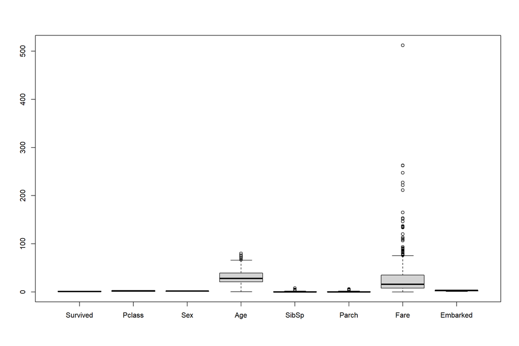

```r
boxplot(titanic)
```

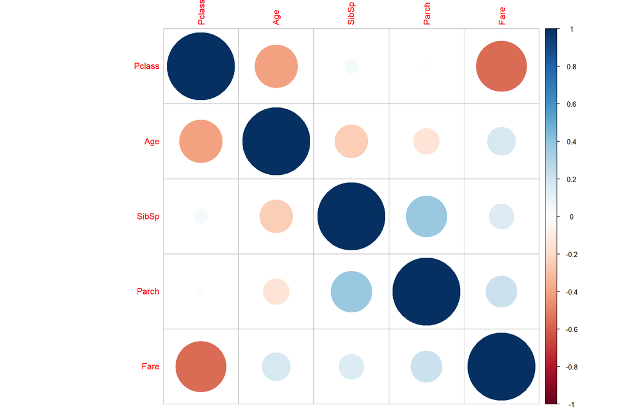

```r
matriz.correlacion<-cor(Filter(is.numeric,titanic))
corrplot(matriz.correlacion)
```

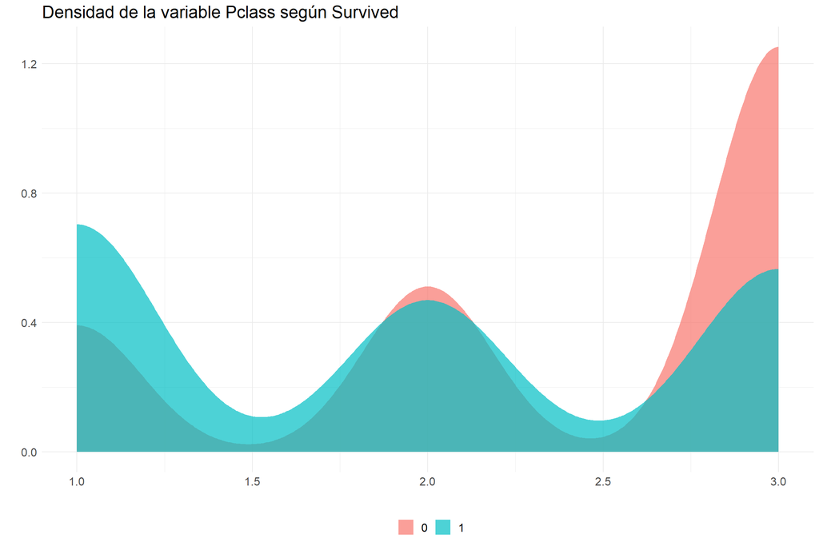

```r
poder.predictivo.numerica(titanic, "Survived","Pclass")
```

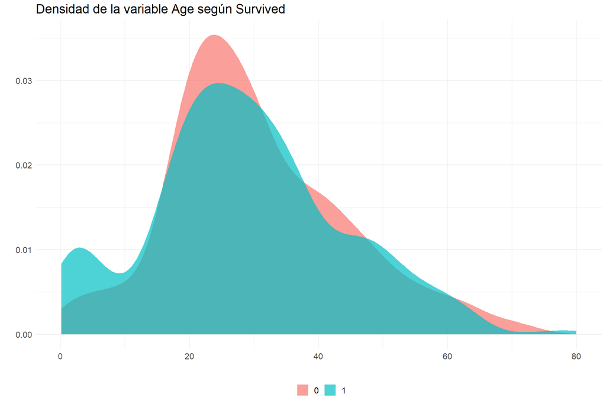

```r
poder.predictivo.numerica(titanic, "Survived","Age")
```

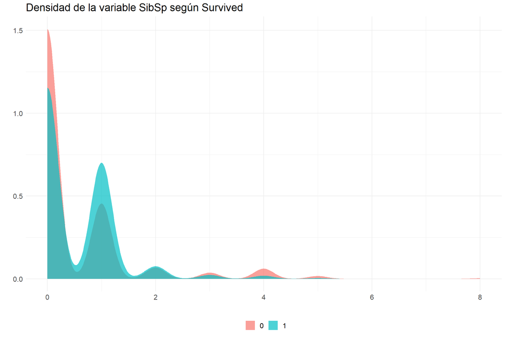

```r
poder.predictivo.numerica(titanic, "Survived","SibSp")
```

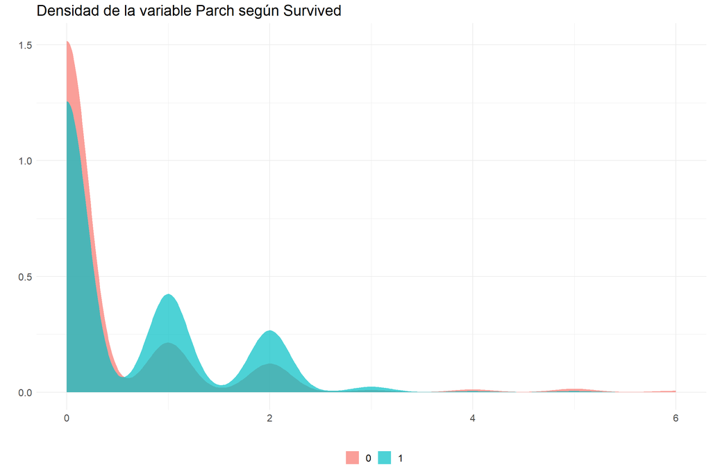

```r
poder.predictivo.numerica(titanic, "Survived","Parch")
```

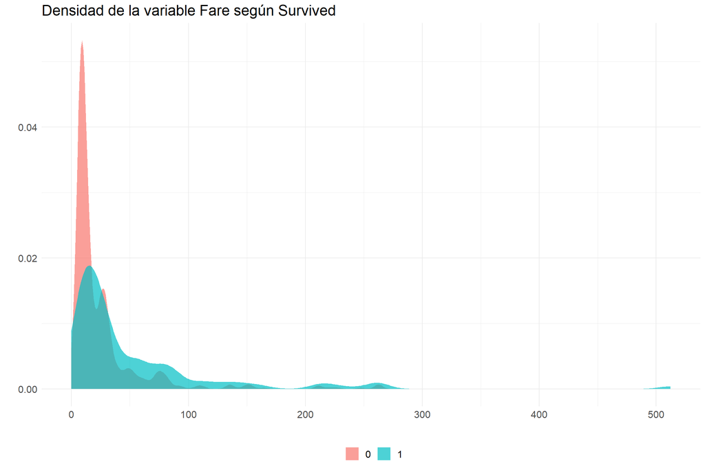

```r
poder.predictivo.numerica(titanic, "Survived","Fare")
```

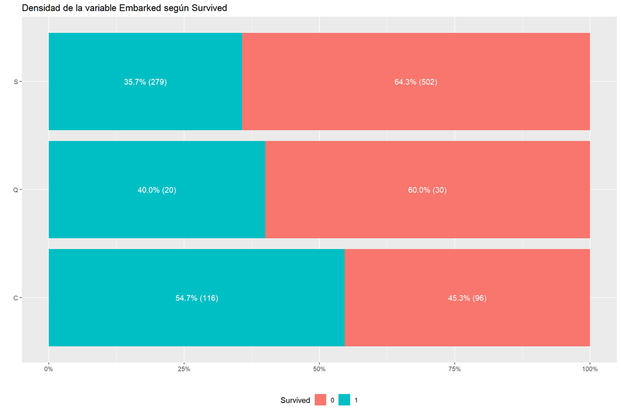

```r
poder.predictivo.categorica(titanic, "Survived","Embarked")
```

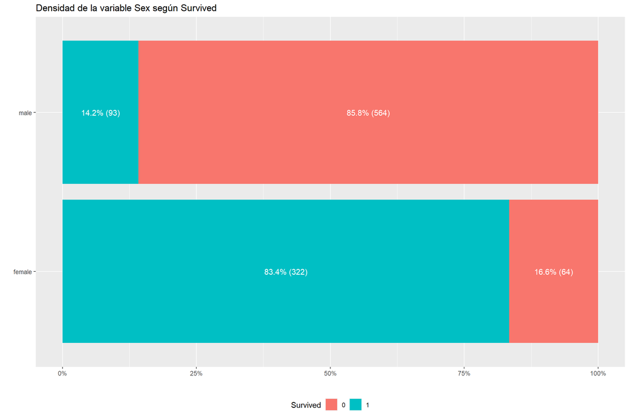

```r
poder.predictivo.categorica(titanic, "Survived","Sex")
```

## 3. ¿Es este problema equilibrado o desequilibrado? Justifique su respuesta.

Es desequilibrado, hay un claro desbalance entre las personas que sobrevivieron y las que no, siendo mucho más las que no

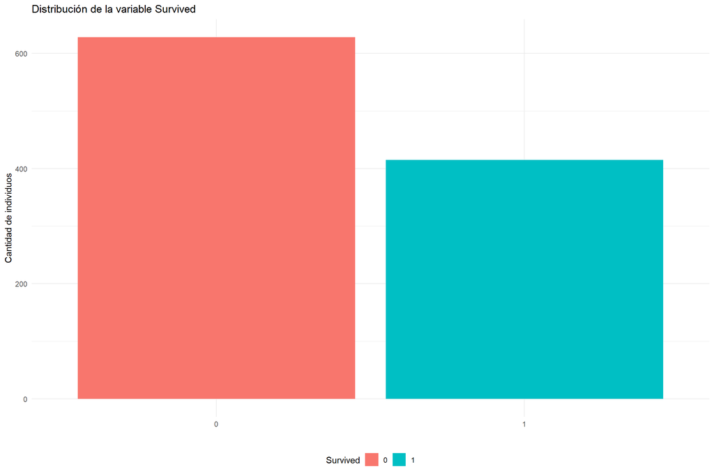

```r
equilibrio.variable.predecir <- function(datos, variable.predecir, ylab = "Cantidad de individuos",
                                        xlab = "", main = paste("Distribución de la variable",variable.predecir), col = NA) {
  gg_color <- function (n) {
     hues <- seq(15, 375, length = n + 1)
     hcl(h = hues, l = 65, c = 100)[1:n]
  }
  if(missing(variable.predecir) | !(variable.predecir %in% colnames(datos))){
    stop("variable.predecir tiene que ser ingresada y ser un nombre de columna", call. = FALSE )
  }
  if(is.character(datos[,variable.predecir]) | is.factor(datos[,variable.predecir])){
    if(length(col) == 0 || is.na(col)){
      col <- gg_color(length(unique(datos[,variable.predecir])))
    }else{
      col <- rep(col,length(unique(datos[,variable.predecir])))
    }
    ggplot(data = datos, mapping = aes_string(x = variable.predecir, fill = variable.predecir)) +
      geom_bar() +
      scale_fill_manual(values = col, name = variable.predecir) +
      labs(x = xlab, y = ylab, title = main) +
      theme_minimal() +
      theme(legend.position = "bottom")
  }else{
    stop("La variable a predecir tienen que ser de tipo factor o character", call. = FALSE )
  }
}
equilibrio.variable.predecir(titanic,"Survived")
```

## 4. Use el método de K vecinos más cercanos en el paquete traineR, con los parámetros que logren el mejor resultado, para generar un modelo predictivo con la tabla titanicV2020.csv usando el 80 % de los datos para la tabla aprendizaje y un 20 % para la tabla testing, luego calcule para los datos de testing la matriz de confusión, la precisión global y la precisión para cada una de las dos categorías. ¿Son buenos los resultados? Explique.

```r
tam<-dim(titanic)[1]

muestra <- sample(1:tam,floor(n*0.20))
testing <- titanic[muestra,]
aprendizaje <- titanic[-muestra,]

modelo<-train.knn(Survived~.,data=aprendizaje)
prediccion <- predict(modelo, testing, type = "class")

MC <- confusion.matrix(testing, prediccion)
general.indexes(mc = MC)
```

```
Confusion Matrix:
    prediction
real   0   1
   0 143  18
   1  24  70

Overall Accuracy: 0.8353
Overall Error:    0.1647

Category Accuracy:

            0            1
     0.888199     0.744681
```

```r
indices<-indices.general(MC)
```

Aunque los resultados no son malos, los falson negativos son considerablemente altos en proporcion con los positivos verdaderos. Yo consideraría este modelo como intermedio

## 5. Repita el item 4), pero esta vez, seleccione las 5 variables que, según su criterio, tienen mejor poder predictivo. ¿Mejoran los resultados?

```r
tam<-dim(titanic)[1]

muestra <- sample(1:tam,floor(n*0.20))
testing <- titanic[muestra,]
aprendizaje <- titanic[-muestra,]

modelo<-train.knn(Survived~+Age+Pclass+Fare+Sex,data=aprendizaje,kmax=floor(sqrt(n)))
prediccion <- predict(modelo, testing, type = "class")

MC <- confusion.matrix(testing, prediccion)
general.indexes(mc = MC)
```

```
Confusion Matrix:
    prediction
real   0   1
   0 125  19
   1  27  84

Overall Accuracy: 0.8196
Overall Error:    0.1804

Category Accuracy:

            0            1
     0.868056     0.756757
```

No, en realidad disminuyó precisión.

## 6. Usando la función programada en el ejercicio 1, los datos titanicV2020.csv y los modelos generados arriba construya un DataFrame de manera que en cada una de las filas aparezca un modelo predictivo y en las columnas aparezcan los índices Precisión Global, Error Global Precisión Positiva (PP), Precisión Negativa (PN), Falsos Positivos (FP), los Falsos Negativos (FN), la Asertividad Positiva (AP) y la Asertividad Negativa (AN). ¿Cuál de los modelos es mejor para estos datos?

```r
indices2<-indices.general(MC)
indices2$`Precisión por categoría`<-sprintf("%f,%f", indices2$`Precisión por categoría`[1], indices2$`Precisión por categoría`[2])

indices$`Precisión por categoría`<-sprintf("%f,%f", indices$`Precisión por categoría`[1], indices$`Precisión por categoría`[2])

rbind(as.data.frame(indices),as.data.frame(indices2))
```

```
   Precisión.Global Error.Global Precisión.por.categoría Falsos.positivos
0         0.8352941    0.1647059       0.888199,0.744681        0.1118012
01        0.8196078    0.1803922       0.868056,0.756757        0.1319444
   Falsos.negativos Asertividad.Positiva Asertvidad.Negativa
0         0.2553191            0.7954545           0.8562874
01        0.2432432            0.8155340           0.8223684
```

# Ejercicio 4

En este ejercicio vamos a predecir números escritos a mano (Hand Written Digit Recognition), la tabla de de datos está en el archivo ZipData 2020.csv. En la figura siguiente se ilustran los datos:

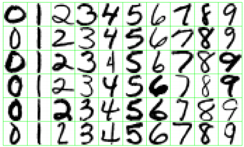

```r
knitr::include_graphics("Captura.png")
```

Los datos de este ejemplo vienen de los códigos postales escritos a mano en sobres del correo postal de EE.UU. Las imágenes son de 16 × 16 en escala de grises, cada píxel va de intensidad de −1 a 1 (de blanco a negro). Las imágenes se han normalizado para tener aproximadamente el mismo tamaño y orientación. La tarea consiste en predecir, a partir de la matriz de 16 × 16de intensidades de cada píxel, la identidad de cada imagen (0, 1, . . . , 9) de forma rápida y precisa. Si es lo suficientemente precisa, el algoritmo resultante se utiliza como parte de un procedimiento de selección automática para sobres. Este es un problema de clasificación para el cual la tasa de error debe mantenerse muy baja para evitar la mala dirección de correo. La columna 1 tiene la variable a predecir Número codificada como sigue: 0=‘cero’; 1=‘uno’; 2=‘dos’; 3=‘tres’; 4=‘cuatro’; 5=‘cinco’;6=‘seis’; 7=‘siete’; 8=‘ocho’ y 9=‘nueve’, las demás columnas son las variables predictivas, además cada fila de la tabla representa un bloque 16 × 16 por lo que la matriz tiene 256 variables predictivas. Para esto realice lo siguiente (podría tomar varios minutos los cálculos):

## 1. Cargue la tabla de datos ZipData 2020.csv en R.

```r
Datos <- read.table("Datos Tarea/ZipData_2020.csv", sep = ";", dec = ".", header = TRUE, stringsAsFactors = T)
```

## 2. ¿Es este problema equilibrado o desequilibrado? Justifique su respuesta.

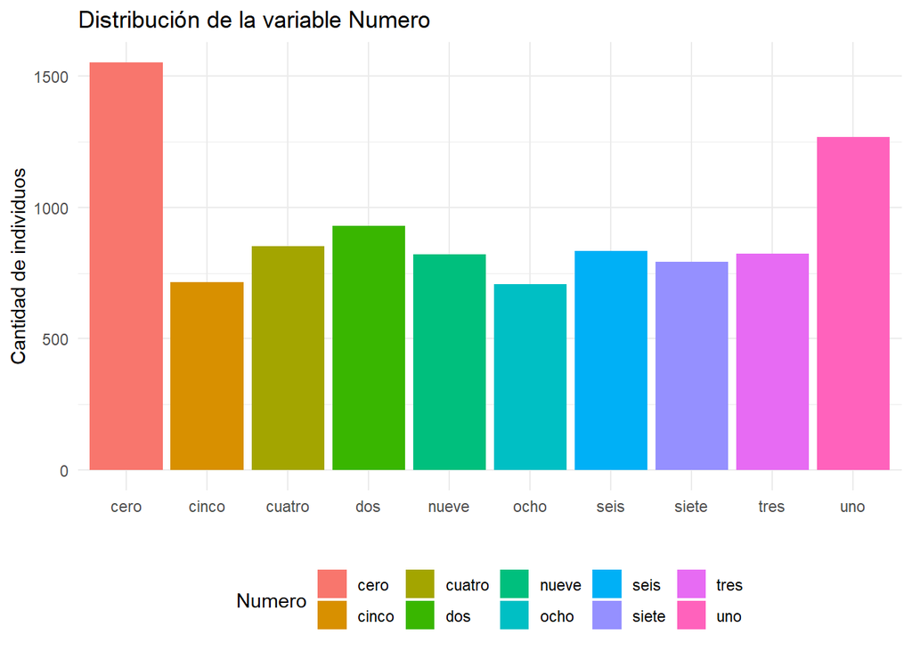

```r
equilibrio.variable.predecir(Datos,"Numero")
```

Es desequilibrada al menos entre los números cero y uno con los demás.

3. Use el método de K vecinos más cercanos en el paquete traineR (con los parámetros por defecto) para generar un modelo predictivo para la tabla ZipData 2020.csv usando el 80 % de los datos para la tabla aprendizaje y un 20 % para la tabla testing, luego calcule para los datos de testing la matriz de confusión, la precisión global y la precisión para cada una de las categorías. ¿Son buenos los resultados? Explique

```r
tam<-dim(Datos)
n<-tam[1]
muestra <- sample(1:tam, floor(n*0.20))
testing <- Datos[muestra,]
aprendizaje <- Datos[-muestra,]

modelo <- train.knn(Numero~. , aprendizaje)
modelo
```

```
Call:
kknn::train.kknn(formula = Numero ~ ., data = aprendizaje)

Type of response variable: nominal
Minimal misclassification: 0.04261325
Best kernel: optimal
Best k: 6
```

```r
prediccion <- predict(modelo, testing, type = "class")

MC <- confusion.matrix(testing, prediccion)
general.indexes(mc = MC)
```

```
Confusion Matrix:
        prediction
real     cero cinco cuatro dos nueve ocho seis siete tres uno
  cero    320     0      0   1     0    0    0     1    1   0
  cinco     3   139      0   1     1    0    4     0    3   0
  cuatro    0     0    168   1     6    0    1     3    0   3
  dos       2     0      1 174     0    3    1     4    4   0
  nueve     0     0      2   0   144    0    0     1    1   0
  ocho      4     0      0   2     2  133    0     3    4   1
  seis      4     0      0   1     0    0  159     0    1   1
 [ reached getOption("max.print") -- omitted 3 rows ]

Overall Accuracy: 0.9554
Overall Error:    0.0446

Category Accuracy:

         cero        cinco       cuatro          dos        nueve         ocho         seis        siete         tres          uno
     0.990712     0.920530     0.923077     0.920635     0.972973     0.892617     0.957831     0.978261     0.948718     0.996109
```

```r
indices.general(MC)
```

```
$`Precisión Global`
[1] 0.9553523

$`Error Global`
[1] 0.04464766

$`Precisión por categoría`
     cero     cinco    cuatro       dos     nueve      ocho      seis     siete
0.9907121 0.9205298 0.9230769 0.9206349 0.9729730 0.8926174 0.9578313 0.9782609
     tres       uno
0.9487179 0.9961089

$`Falsos positivos`
cero
   0

$`Falsos negativos`
     cinco
0.01986755

$`Asertividad Positiva`
    cinco
0.9788732

$`Asertvidad Negativa`
     cero
0.9580838
```